# AIHA Abstract Analysis

# 1 Introduction

The following data exploration will produce descriptive statistics and explore the distribution of data in terms of duration of exposure for use of an AIHA abstract.

# 2 Data Exclusion

For the purposes of this analysis, we will begin by excluding observations taking place in 2026 so we can have full year data:

```r
study_dat |>
  filter(year == 2026) |>
  count()
```

```
##   n
## 1 0
```

```r
study_dat <- study_dat |>
  filter(year != 2026)
```

# 3 General Data Summaries

How many observations?

```r
nrow(study_dat)
```

```
## [1] 2404
```

How many are detect vs. non-detect?

```r
study_dat |>
count(loq) |>
  mutate(pct = n / sum(n) * 100)
```

```
##     loq    n      pct
## 1 FALSE 1401 58.27787
## 2  TRUE 1003 41.72213
```

## 3.1 Study Period

I.E., what dates/years are covered by the time series data?

```r
range(study_dat$date_sampled)
```

```
## [1] "2004-02-23" "2025-12-30"
```

### 3.1.1 Detected Data

```r
study_dat |>
  filter(loq == FALSE) |>
  summarize(min(date_sampled), max(date_sampled))
```

```
##   min(date_sampled) max(date_sampled)
## 1        2006-11-14        2025-12-30
```

Among our *detected* measurements, we have samples ranging from 11/14/2006 to 12/30/2025.

```r
study_dat |>
  filter(loq == FALSE) |>
  group_by(year) |>
  count() |>
  arrange(desc(n))
```

```
## # A tibble: 20 × 2
## # Groups:   year [20]
##    year      n
##    <fct> <int>
##  1 2024    256
##  2 2025    185
##  3 2011    113
##  4 2016    109
##  5 2023    108
##  6 2017    104
##  7 2012     86
##  8 2014     62
##  9 2013     59
## 10 2022     56
## 11 2018     52
## 12 2019     51
## 13 2020     41
## 14 2021     34
## 15 2010     33
## 16 2015     28
## 17 2007     12
## 18 2009      7
## 19 2006      3
## 20 2008      2
```

### 3.1.2 Non-Detects

```r
study_dat |>
  filter(loq == TRUE) |>
  summarize(min(date_sampled), max(date_sampled))
```

```
##   min(date_sampled) max(date_sampled)
## 1        2004-02-23        2025-03-05
```

Among our *non-detect* samples, we have samples ranging from 2/23/2004 to 3/05/2025.

# 4 Subsetting datasets

We are now going to make some new datasets, one which contains just our non-detect measurements, one with our detected measurements, and one that has both.

```r
all_data <- study_dat
nrow(all_data)
```

```
## [1] 2404
```

```r
non_detects <- study_dat |>
  filter(loq == TRUE)
nrow(non_detects)
```

```
## [1] 1003
```

```r
study_dat <- study_dat |>
  filter(loq == FALSE)
nrow(study_dat)
```

```
## [1] 1401
```

# 5 Non-Detect examination

Min and max number per year:

```r
non_detects |>
  group_by(year) |>
  summarize(n = n()) |>
  arrange(desc(n))
```

```
## # A tibble: 21 × 2
##    year      n
##    <fct> <int>
##  1 2024    139
##  2 2011    103
##  3 2012     90
##  4 2016     82
##  5 2017     82
##  6 2019     70
##  7 2013     66
##  8 2014     63
##  9 2023     60
## 10 2018     51
## # ℹ 11 more rows
```

How many non-detects relative to detects per year?

```r
all_data |>
  group_by(year) |>
count(loq) |>
  mutate(pct = n / sum(n) * 100)
```

```
## # A tibble: 41 × 4
## # Groups:   year [21]
##    year  loq       n   pct
##    <fct> <lgl> <int> <dbl>
##  1 2004  TRUE      2 100
##  2 2006  FALSE     3  60
##  3 2006  TRUE      2  40
##  4 2007  FALSE    12  70.6
##  5 2007  TRUE      5  29.4
##  6 2008  FALSE     2  40
##  7 2008  TRUE      3  60
##  8 2009  FALSE     7  29.2
##  9 2009  TRUE     17  70.8
## 10 2010  FALSE    33  53.2
## # ℹ 31 more rows
```

Plotting this:

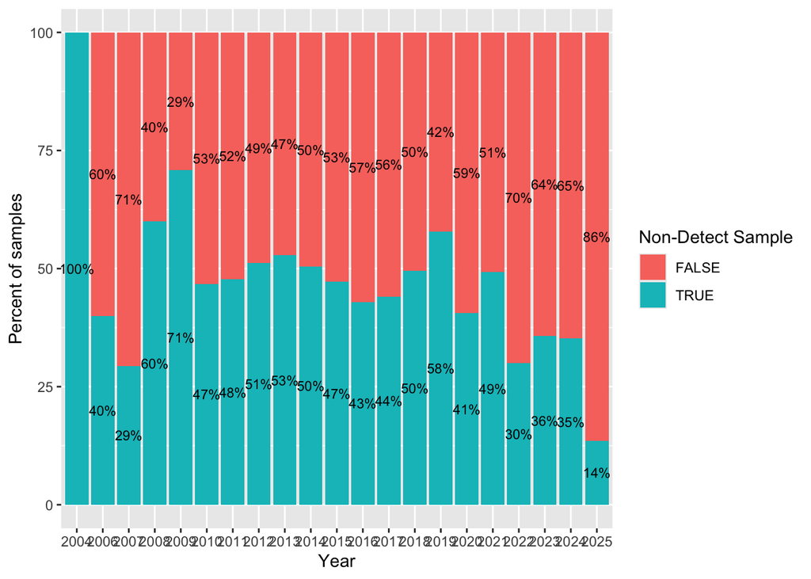

```r
  loq_summary <- all_data |>
  group_by(year) |>
  count(loq) |>
  mutate(pct = n / sum(n) * 100) |>
  ungroup()


ggplot(loq_summary, aes(x = factor(year), y = pct, fill = loq)) +
  geom_col() +
  geom_text(aes(label = paste0(round(pct), "%")),
            position = position_stack(vjust = 0.5), size = 3) +
  labs(x = "Year", y = "Percent of samples", fill = "Non-Detect Sample")
```

Just eyeballing this, it looks like there could be a significant trend in decreased percent of non-detect samples relative to all samples taken year by year. That could be an interesting model option to investigate further down in the temporal trend section.

## 5.1 How many samples per year?

```r
#reported
study_dat |>
  group_by(year) |>
  summarize(n_year = n()) |>
  summarize(
    min_n = min(n_year),
    max_n = max(n_year)
  )
```

```
## # A tibble: 1 × 2
##   min_n max_n
##   <int> <int>
## 1     2   256
```

```r
study_dat |>
  group_by(year) |>
  summarize(n_year = n())
```

```
## # A tibble: 20 × 2
##    year  n_year
##    <fct>  <int>
##  1 2006       3
##  2 2007      12
##  3 2008       2
##  4 2009       7
##  5 2010      33
##  6 2011     113
##  7 2012      86
##  8 2013      59
##  9 2014      62
## 10 2015      28
## 11 2016     109
## 12 2017     104
## 13 2018      52
## 14 2019      51
## 15 2020      41
## 16 2021      34
## 17 2022      56
## 18 2023     108
## 19 2024     256
## 20 2025     185
```

```r
#all measurements
all_data |>
  group_by(year) |>
  summarize(n_year = n())
```

```
## # A tibble: 21 × 2
##    year  n_year
##    <fct>  <int>
##  1 2004       2
##  2 2006       5
##  3 2007      17
##  4 2008       5
##  5 2009      24
##  6 2010      62
##  7 2011     216
##  8 2012     176
##  9 2013     125
## 10 2014     125
## # ℹ 11 more rows
```

## 5.2 Plotting number of samples per year

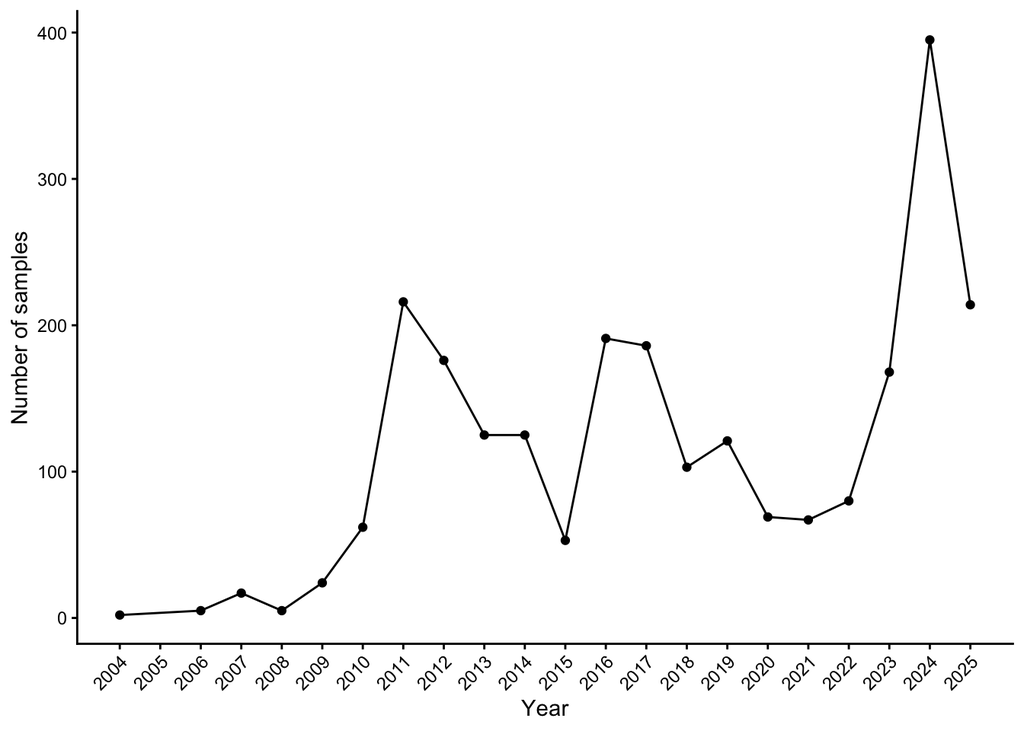

```r
samples_per_year <- all_data |>
 group_by(year) |>
  summarize(n_year = n()) |>
  mutate(year = as.numeric(as.character(year)))


fig1 <- ggplot(samples_per_year, aes(x =as.numeric(year), y = n_year)) +
  geom_point()+
  geom_line()+
  labs(x = "Year", y = "Number of samples")+
  scale_x_continuous(breaks = seq(min(samples_per_year$year), max(samples_per_year$year), 1)) +
   theme_classic()+

  theme(plot.title = element_text(hjust = 0.5),
    plot.subtitle = element_text(hjust = 0.5),
    axis.text.x = element_text(angle = 45, hjust = 1))

print(fig1)
```

```r
ggsave("../Output/samples_per_year.png", fig1,
       width = 6,
       height = 4)
```

Note that we are missing data for the year 2005!

## 5.3 Annual plot with LOQ

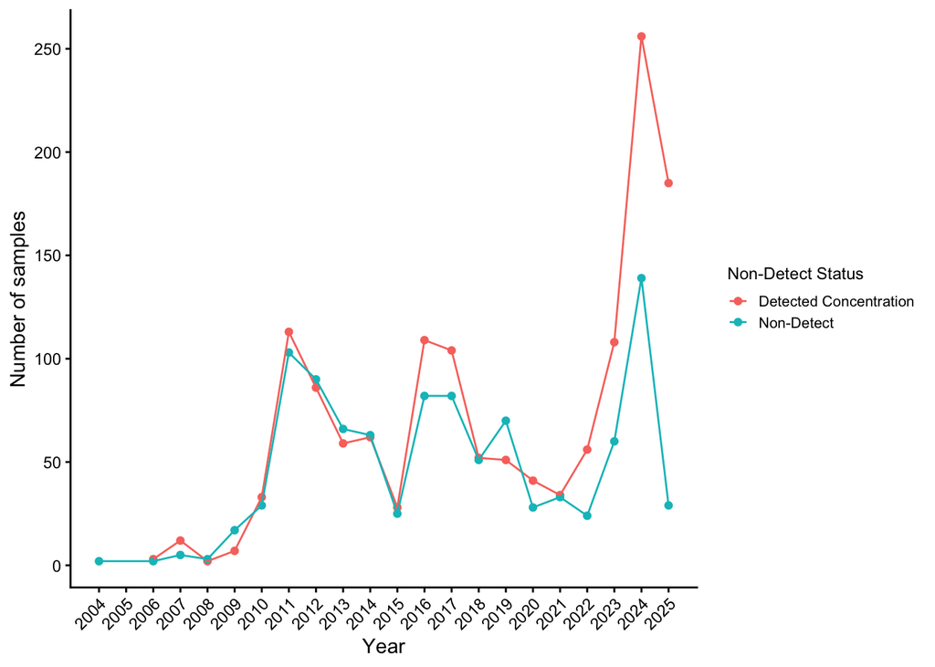

```r
samples_by_loq <- all_data |>
  count(year, loq) |>
  mutate(year = as.numeric(as.character(year)),
         loq = if_else(loq, "Non-Detect", "Detected Concentration"))

fig2 <- ggplot(samples_by_loq, aes(x = year, y = n, color = loq)) +
  geom_point() +
  geom_line() +
  scale_x_continuous(breaks = seq(min(samples_by_loq$year), max(samples_by_loq$year), 1)) +
  scale_y_continuous(breaks = seq(0, 300, 50)) +
  labs(x = "Year", y = "Number of samples", color = "Non-Detect Status") +
  theme_classic() +
  theme(
    plot.subtitle = element_text(hjust = 0.5),
    axis.text.x = element_text(angle = 45, hjust = 1),
    legend.title = element_text(size = 9),
    legend.text  = element_text(size = 8),
    legend.key.size = unit(0.4, "cm")
  )

print(fig2)
```

```r
ggsave("../Output/samples_per_year_and_LOQ.png", fig2,
       width = 8,
       height = 4)
```

## 5.4 Duration

### 5.4.1 N by duration

```r
study_dat |>
  group_by(duration) |>
  count()
```

```
## # A tibble: 4 × 2
## # Groups:   duration [4]
##   duration        n
##   <chr>       <int>
## 1 Long-Term     685
## 2 Medium-Term   632
## 3 Short-Term     75
## 4 Task-Based      9
```

### 5.4.2 Concentration by Duration

```r
study_dat |>
  group_by(duration) |>
  summarize(
    min_conc = min(silica_conc, na.rm = TRUE),
    max_conc = round(max(silica_conc, na.rm = TRUE),1),
    n_total  = n(),
    below_lod = sum(lod),
    pct_lod = round((100 * below_lod / n_total),1),
    over_AL  = sum(silica_conc > 25, na.rm = TRUE),
    over_PEL = sum(silica_conc > 50, na.rm = TRUE),
    pct_over_AL  = round((100 * over_AL / n_total),1),
    pct_over_PEL = round((100 * over_PEL / n_total),1)
  )
```

```
## # A tibble: 4 × 10
##   duration    min_conc max_conc n_total below_lod pct_lod over_AL over_PEL
##   <chr>          <dbl>    <dbl>   <int>     <int>   <dbl>   <int>    <int>
## 1 Long-Term          0    5093      685        33     4.8     436      291
## 2 Medium-Term        0    5711.     632        34     5.4     581      417
## 3 Short-Term         0    6526.      75         5     6.7      73       71
## 4 Task-Based       392    7373.       9         2    22.2       9        9
## # ℹ 2 more variables: pct_over_AL <dbl>, pct_over_PEL <dbl>
```

How many were 0 per duration group?

```r
study_dat |>
  mutate(zero = silica_conc == 0) |>
  group_by(duration) |>
  summarize(
    n_total  = n(),
    n_zeros= sum(zero),
    pct_zero = round((100 * n_zeros / n_total),1)
  )
```

```
## # A tibble: 4 × 4
##   duration    n_total n_zeros pct_zero
##   <chr>         <int>   <int>    <dbl>
## 1 Long-Term       685       3      0.4
## 2 Medium-Term     632       1      0.2
## 3 Short-Term       75       2      2.7
## 4 Task-Based        9       0      0
```

## 5.5 Over PEL

Let’s start by summarizing in terms of by year:

```r
study_dat <- study_dat |>
  mutate(over_PEL = silica_conc >= 50)

over_PEL_annual <- study_dat |>
  group_by(year) |>
  summarize(annual_pct_over_pel = round(mean(over_PEL == "TRUE")*100, 2))

over_PEL_annual
```

```
## # A tibble: 20 × 2
##    year  annual_pct_over_pel
##    <fct>               <dbl>
##  1 2006                 33.3
##  2 2007                 41.7
##  3 2008                 50
##  4 2009                 85.7
##  5 2010                 72.7
##  6 2011                 57.5
##  7 2012                 70.9
##  8 2013                 64.4
##  9 2014                 61.3
## 10 2015                 71.4
## 11 2016                 79.8
## 12 2017                 68.3
## 13 2018                 73.1
## 14 2019                 60.8
## 15 2020                 75.6
## 16 2021                 61.8
## 17 2022                 28.6
## 18 2023                 51.8
## 19 2024                 44.1
## 20 2025                 35.7
```

Next, let’s summarize in terms of duration category:

```r
over_PEL_duration <- study_dat |>
  group_by(duration) |>
  summarize(annual_pct_over_pel = round(mean(over_PEL == "TRUE")*100, 2))

over_PEL_duration
```

```
## # A tibble: 4 × 2
##   duration    annual_pct_over_pel
##   <chr>                     <dbl>
## 1 Long-Term                  42.6
## 2 Medium-Term                66.0
## 3 Short-Term                 94.7
## 4 Task-Based                100
```

# 6 Plots

## 6.1 AL and PEL plot

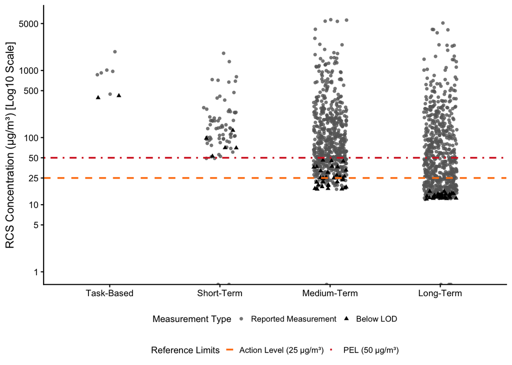

```r
# --- Prep: order duration groups, label lod status ---
plot_dat <- study_dat %>%
  mutate(
    duration = factor(duration,
                         levels = c("Task-Based", "Short-Term", "Medium-Term", "Long-Term")),
    lod_status = factor(lod, levels = c(FALSE, TRUE),
                         labels = c("Reported Measurement", "Below LOD"))
  )

al_pel_plot <- ggplot(plot_dat, aes(x = duration, y = silica_conc, shape = lod_status, color = lod_status)) +

  # Reported Measurement: drawn first (bottom layer), semi-transparent
  geom_jitter(
    data = subset(plot_dat, lod_status == "Reported Measurement"),
    width = 0.15, size = 1.3, alpha = 0.8
  ) +

  # Below LOD: drawn second (top layer), fully opaque, no alpha
  geom_jitter(
    data = subset(plot_dat, lod_status == "Below LOD"),
    width = 0.15, size = 1.3, alpha = 1
  ) +

  # Reference limits (fixed colors via override so they don't clash with the point color scale)
  geom_hline(aes(yintercept = 25, linetype = "Action Level (25 µg/m³)"),
             color = "#ff7f0e", linewidth = 0.8) +
  geom_hline(aes(yintercept = 50, linetype = "PEL (50 µg/m³)"),
             color = "#d62728", linewidth = 0.8) +
  scale_y_log10(
    breaks = c(1, 5, 10, 25, 50, 100, 500, 1000, 5000),
    limits = c(1, 6000)
  ) +
  scale_shape_manual(
    name = "Measurement Type",
    values = c("Reported Measurement" = 16,
               "Below LOD" = 17)
  ) +
  scale_color_manual(
    name = "Measurement Type",
    values = c("Reported Measurement" = "grey40",
               "Below LOD" = "black")
  ) +
  scale_linetype_manual(
    name = "Reference Limits",
    values = c("Action Level (25 µg/m³)" = "dashed",
               "PEL (50 µg/m³)" = "dotdash")
  ) +
  guides(
    linetype = guide_legend(override.aes = list(colour = c("#ff7f0e", "#d62728")))
  ) +
  labs(
    x = NULL,
    y = "RCS Concentration (µg/m³) [Log10 Scale]"
  ) +
  theme_classic() +
  theme(
    plot.title = element_text(hjust = 0.5),
    legend.position = "bottom",
    legend.box = "vertical",
    legend.key.size = unit(0.3, "cm"),
     legend.text = element_text(size = 8),
    legend.title = element_text(size = 9)
  )

print(al_pel_plot)
```

```r
ggsave("../Output/duration_concentration_plot.png", al_pel_plot)
```

## 6.2 Over PEL Plot:

```r
study_dat <- study_dat |>
  mutate(over_PEL = silica_conc > 50)

over_PEL <- study_dat |>
  group_by(year) |>
  summarize(annual_pct_over_pel = round(mean(over_PEL == "TRUE")*100, 2))

over_PEL
```

```
## # A tibble: 20 × 2
##    year  annual_pct_over_pel
##    <fct>               <dbl>
##  1 2006                 33.3
##  2 2007                 41.7
##  3 2008                 50
##  4 2009                 85.7
##  5 2010                 72.7
##  6 2011                 57.5
##  7 2012                 70.9
##  8 2013                 64.4
##  9 2014                 61.3
## 10 2015                 71.4
## 11 2016                 79.8
## 12 2017                 67.3
## 13 2018                 73.1
## 14 2019                 60.8
## 15 2020                 75.6
## 16 2021                 61.8
## 17 2022                 28.6
## 18 2023                 51.8
## 19 2024                 44.1
## 20 2025                 35.7
```

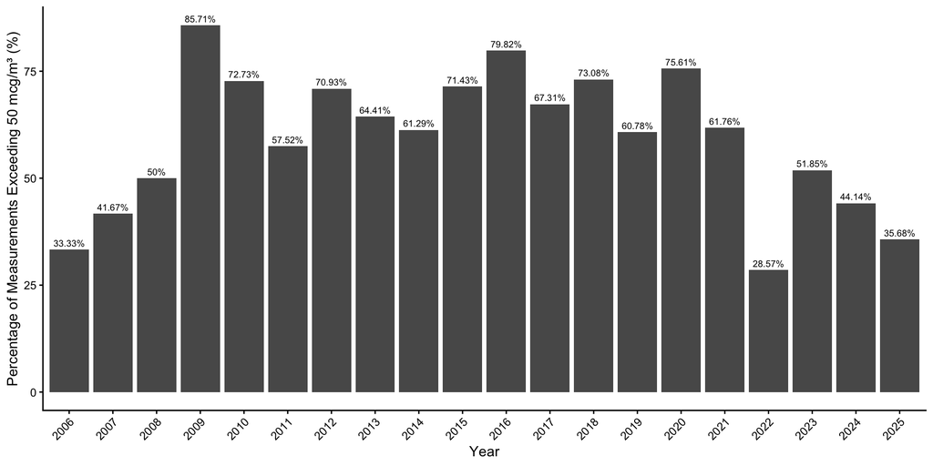

```r
PEL_plot <-  ggplot(over_PEL, aes(year, annual_pct_over_pel))+
  geom_col()+
  labs(x = "Year", y = "Percentage of Measurements Exceeding 50 mcg/m³ (%)") +

 geom_text(aes(label = paste0(annual_pct_over_pel, "%"), vjust = -0.5), size = 2.5)+

   theme_classic()+

  theme(plot.title = element_text(hjust = 0.5),
    plot.subtitle = element_text(hjust = 0.5),
    axis.text.x = element_text(angle = 45, hjust = 1))

print(PEL_plot)
```

```r
ggsave("../Output/overPEL_plot.png", PEL_plot,
       width = 8, height = 5)
```

What about Over PEL by Duration??

```r
over_PEL_duration <- study_dat |>
  group_by(year,duration) |>
  summarize(annual_pct_over_pel = round(mean(over_PEL == "TRUE")*100, 2))

over_PEL_duration
```

```
## # A tibble: 62 × 3
## # Groups:   year [20]
##    year  duration    annual_pct_over_pel
##    <fct> <chr>                     <dbl>
##  1 2006  Medium-Term                50
##  2 2006  Short-Term                  0
##  3 2007  Long-Term                  16.7
##  4 2007  Medium-Term                80
##  5 2007  Short-Term                  0
##  6 2008  Medium-Term                50
##  7 2009  Long-Term                 100
##  8 2009  Medium-Term                83.3
##  9 2010  Long-Term                  62.5
## 10 2010  Medium-Term                76.9
## # ℹ 52 more rows
```

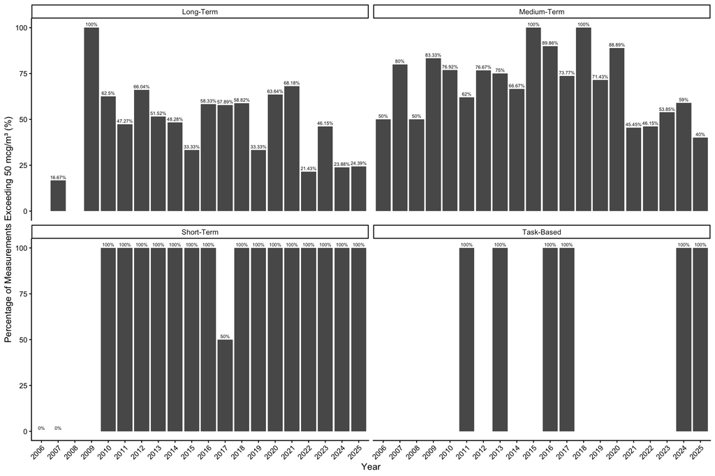

```r
over_PEL_duration_plot <- ggplot(over_PEL_duration, aes(year, annual_pct_over_pel))+
  facet_wrap(~duration)+
  geom_col()+
  labs(x = "Year", y = "Percentage of Measurements Exceeding 50 mcg/m³ (%)")+

 geom_text(aes(label = paste0(annual_pct_over_pel, "%"), vjust = -0.5), size = 2)+

   theme_classic()+

  theme(plot.title = element_text(hjust = 0.5),
    plot.subtitle = element_text(hjust = 0.5),
    axis.text.x = element_text(angle = 45, hjust = 1))

print(over_PEL_duration_plot)
```

```r
ggsave("../Output/overPEL_duration_plot.png", over_PEL_duration_plot,
       width = 12, height = 8.5)
```

# 7 Temporal Trends

## 7.1 LOQ trends over time

I’m interested to see if the percentage of non-detects relative to all samples taken changed significantly over the study period.

```r
loq_summary <- all_data |>
  group_by(year) |>
  count(loq) |>
  mutate(pct = n / sum(n) * 100) |>
  ungroup() |>
  filter(loq == TRUE)

loq_dat_clean <- loq_summary |>
  mutate(year = as.numeric(as.character(year))) |>
  arrange(year) |>
  mutate(year_counter = dense_rank(year) - 1)

loq_dat_clean |>
  distinct(year, year_counter) |>
  arrange(year)
```

```
## # A tibble: 21 × 2
##     year year_counter
##    <dbl>        <dbl>
##  1  2004            0
##  2  2006            1
##  3  2007            2
##  4  2008            3
##  5  2009            4
##  6  2010            5
##  7  2011            6
##  8  2012            7
##  9  2013            8
## 10  2014            9
## # ℹ 11 more rows
```

```r
head(loq_dat_clean)
```

```
## # A tibble: 6 × 5
##    year loq       n   pct year_counter
##   <dbl> <lgl> <int> <dbl>        <dbl>
## 1  2004 TRUE      2 100              0
## 2  2006 TRUE      2  40              1
## 3  2007 TRUE      5  29.4            2
## 4  2008 TRUE      3  60              3
## 5  2009 TRUE     17  70.8            4
## 6  2010 TRUE     29  46.8            5
```

```r
loq_mod <- lm(pct~ year_counter, data = loq_dat_clean)

summary(loq_mod)
```

```
##
## Call:
## lm(formula = pct ~ year_counter, data = loq_dat_clean)
##
## Residuals:
##     Min      1Q  Median      3Q     Max
## -30.607  -6.012   0.982   2.264  36.821
##
## Coefficients:
##              Estimate Std. Error t value Pr(>|t|)
## (Intercept)    63.179      6.045  10.452 2.57e-09 ***
## year_counter   -1.580      0.517  -3.057  0.00649 **
## ---
## Signif. codes:  0 '***' 0.001 '**' 0.01 '*' 0.05 '.' 0.1 ' ' 1
##
## Residual standard error: 14.35 on 19 degrees of freedom
## Multiple R-squared:  0.3296, Adjusted R-squared:  0.2944
## F-statistic: 9.343 on 1 and 19 DF,  p-value: 0.006493
```

```r
confint(loq_mod)
```

```
##                  2.5 %     97.5 %
## (Intercept)  50.528036 75.8306660
## year_counter -2.662587 -0.4982029
```

## 7.2 Median concentration reported per year

The OSHA citations database was used to analyze the median concentration reported per year. We can replicate the same analysis:

Do we have all of the years covered by this data?

```r
study_dat |>
  select(year) |>
  unique()
```

```
##      year
## 1    2025
## 186  2024
## 442  2023
## 550  2022
## 606  2021
## 640  2020
## 681  2019
## 732  2018
## 758  2017
## 888  2016
## 997  2015
## 1025 2014
## 1087 2013
## 1146 2012
## 1232 2011
## 1345 2010
## 1378 2009
## 1385 2008
## 1387 2007
## 1399 2006
```

```r
levels(study_dat$year)
```

```
##  [1] "2004" "2006" "2007" "2008" "2009" "2010" "2011" "2012" "2013" "2014"
## [11] "2015" "2016" "2017" "2018" "2019" "2020" "2021" "2022" "2023" "2024"
## [21] "2025"
```

```r
study_dat |>
  filter(year == 2004)
```

```
##  [1] sampling_number establishment   date_sampled    lab_number
##  [5] field_number    time            duration        imis
##  [9] year            silica_conc     lod             loq
## [13] eighthr         log_conc        over_PEL
## <0 rows> (or 0-length row.names)
```

We’re good!

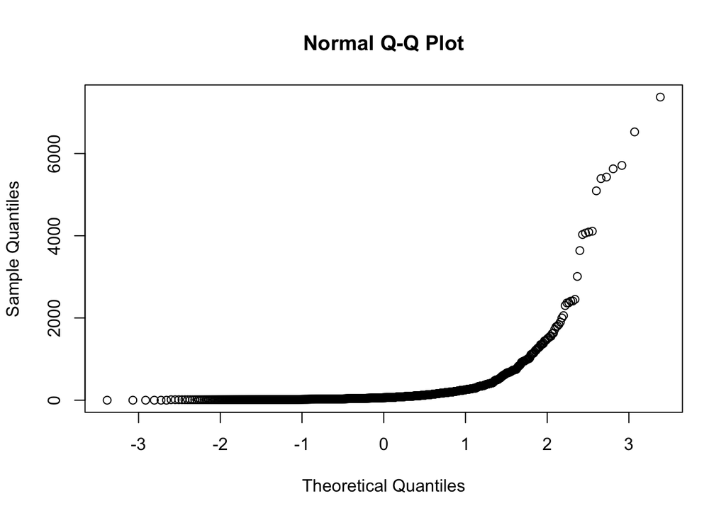

```r
qqnorm(study_dat$silica_conc)
```

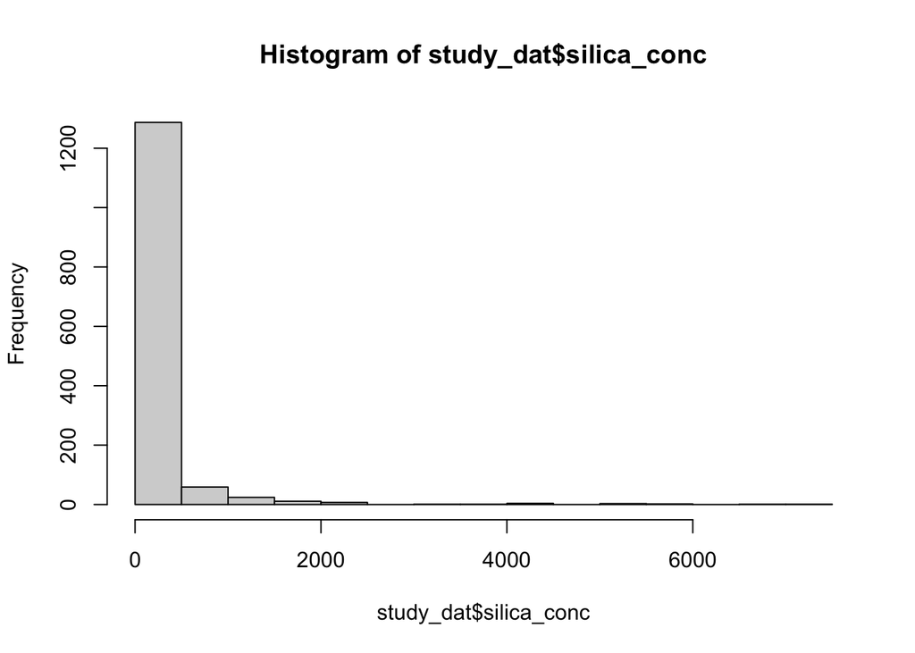

```r
hist(study_dat$silica_conc)
```

```r
shapiro.test(study_dat$silica_conc)
```

```
##
##  Shapiro-Wilk normality test
##
## data:  study_dat$silica_conc
## W = 0.32385, p-value < 2.2e-16
```

Let’s log-transform and check again:

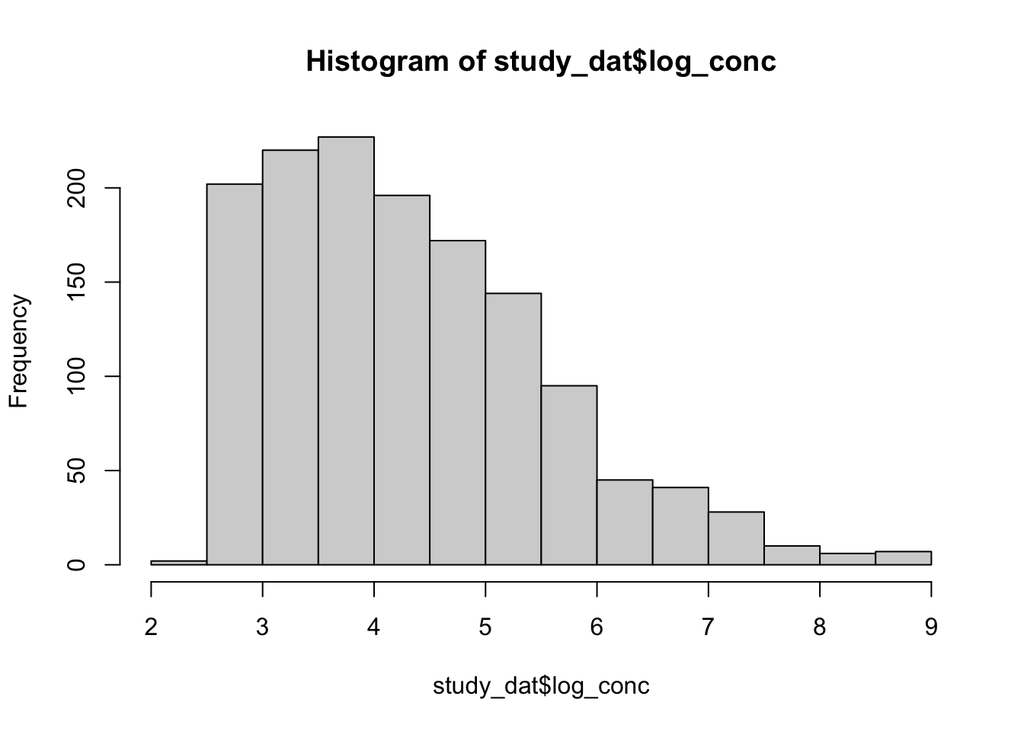

```r
study_dat <- study_dat |>
  mutate(log_conc = log(silica_conc))


hist(study_dat$log_conc)
```

```r
shapiro.test(study_dat$log_conc)
```

```
##
##  Shapiro-Wilk normality test
##
## data:  study_dat$log_conc
## W = NaN, p-value = NA
```

## 7.3 Crude mod:

Issue: we can’t easily log-transform data with so many zeros.

How many zeroes were censored??

```r
study_dat |>
  filter(silica_conc == 0) |>
  count()
```

```
##   n
## 1 6
```

```r
study_dat |>
  filter(silica_conc == 0) |>
  group_by(imis) |>
  count()
```

```
## # A tibble: 1 × 2
## # Groups:   imis [1]
##   imis          n
##   <chr>     <int>
## 1 9010_9130     6
```

```r
no_zeros_dat <- study_dat|>
  filter(silica_conc != 0)
```

```r
mod_median_trend <- lm(log_conc ~ as.numeric(year), data = no_zeros_dat)

summary(mod_median_trend)
```

```
##
## Call:
## lm(formula = log_conc ~ as.numeric(year), data = no_zeros_dat)
##
## Residuals:
##     Min      1Q  Median      3Q     Max
## -2.3904 -0.9218 -0.2010  0.7128  4.4982
##
## Coefficients:
##                   Estimate Std. Error t value Pr(>|t|)
## (Intercept)       5.310524   0.097066   54.71   <2e-16 ***
## as.numeric(year) -0.067006   0.006188  -10.83   <2e-16 ***
## ---
## Signif. codes:  0 '***' 0.001 '**' 0.01 '*' 0.05 '.' 0.1 ' ' 1
##
## Residual standard error: 1.196 on 1393 degrees of freedom
## Multiple R-squared:  0.07764,    Adjusted R-squared:  0.07698
## F-statistic: 117.3 on 1 and 1393 DF,  p-value: < 2.2e-16
```

```r
exp(coef(mod_median_trend))
```

```
##      (Intercept) as.numeric(year)
##      202.4563603        0.9351897
```

```r
ci_log <- cbind(estimate = coef(mod_median_trend), confint(mod_median_trend))
ci_ratio <- exp(ci_log)
ci_ratio
```

```
##                     estimate       2.5 %      97.5 %
## (Intercept)      202.4563603 167.3542392 244.9210609
## as.numeric(year)   0.9351897   0.9239063   0.9466108
```

```r
round((ci_ratio[2, ] - 1) * 100, 1)
```

```
## estimate    2.5 %   97.5 %
##     -6.5     -7.6     -5.3
```

```r
coeftest(mod_median_trend,
         vcov = vcovCL(mod_median_trend,
                       cluster = ~ establishment,
                       type = "HC1"))
```

```
##
## t test of coefficients:
##
##                   Estimate Std. Error t value  Pr(>|t|)
## (Intercept)       5.310524   0.167667 31.6731 < 2.2e-16 ***
## as.numeric(year) -0.067006   0.010538 -6.3587 2.753e-10 ***
## ---
## Signif. codes:  0 '***' 0.001 '**' 0.01 '*' 0.05 '.' 0.1 ' ' 1
```

## 7.4 Median by Duration

```r
median_by_year_and_duration <- no_zeros_dat|>
  group_by(year,duration) |>
  mutate(log_conc = log(silica_conc))


mod_median_trend2 <- lm(log_conc ~ as.numeric(year)*duration, data = median_by_year_and_duration)
summary(mod_median_trend2)
```

```
##
## Call:
## lm(formula = log_conc ~ as.numeric(year) * duration, data = median_by_year_and_duration)
##
## Residuals:
##     Min      1Q  Median      3Q     Max
## -2.0778 -0.8714 -0.2600  0.6414  4.8111
##
## Coefficients:
##                                       Estimate Std. Error t value Pr(>|t|)
## (Intercept)                           4.933257   0.133067  37.073  < 2e-16 ***
## as.numeric(year)                     -0.063616   0.008424  -7.552 7.72e-14 ***
## durationMedium-Term                   0.606833   0.190629   3.183  0.00149 **
## durationShort-Term                    0.970060   0.411840   2.355  0.01864 *
## durationTask-Based                    3.159277   1.028101   3.073  0.00216 **
## as.numeric(year):durationMedium-Term -0.003397   0.012148  -0.280  0.77982
## as.numeric(year):durationShort-Term   0.008259   0.026377   0.313  0.75424
## as.numeric(year):durationTask-Based  -0.026369   0.070907  -0.372  0.71004
## ---
## Signif. codes:  0 '***' 0.001 '**' 0.01 '*' 0.05 '.' 0.1 ' ' 1
##
## Residual standard error: 1.136 on 1387 degrees of freedom
## Multiple R-squared:  0.1721, Adjusted R-squared:  0.168
## F-statistic:  41.2 on 7 and 1387 DF,  p-value: < 2.2e-16
```

# 8 All measurements

### 8.0.1 Over PEL

What if we instead investigate a logistic model that investigates whether the number of facilities exceeding the PEL has changed over the years?

```r
mod_logistic  <- glm(over_PEL~as.numeric(year), data = no_zeros_dat,
                     family = binomial)
summary(mod_logistic)
```

```
##
## Call:
## glm(formula = over_PEL ~ as.numeric(year), family = binomial,
##     data = no_zeros_dat)
##
## Coefficients:
##                  Estimate Std. Error z value Pr(>|z|)
## (Intercept)       1.59471    0.17605   9.058  < 2e-16 ***
## as.numeric(year) -0.08899    0.01100  -8.088 6.04e-16 ***
## ---
## Signif. codes:  0 '***' 0.001 '**' 0.01 '*' 0.05 '.' 0.1 ' ' 1
##
## (Dispersion parameter for binomial family taken to be 1)
##
##     Null deviance: 1910.3  on 1394  degrees of freedom
## Residual deviance: 1841.6  on 1393  degrees of freedom
## AIC: 1845.6
##
## Number of Fisher Scoring iterations: 4
```

```r
extract_eq(mod_logistic)
```

$$\log\left[ \frac { P( \operatorname{over\_PEL} = \operatorname{TRUE} )
}{ 1 - P( \operatorname{over\_PEL} = \operatorname{TRUE} ) } \right] =
\alpha + \beta_{1}(\operatorname{as.numeric(year)})$$

```r
coeftest(mod_logistic,
         vcov = vcovCL(mod_logistic,
                       cluster = ~ establishment,
                       type = "HC1"))
```

```
##
## z test of coefficients:
##
##                   Estimate Std. Error z value  Pr(>|z|)
## (Intercept)       1.594709   0.275041  5.7981 6.708e-09 ***
## as.numeric(year) -0.088988   0.018105 -4.9152 8.871e-07 ***
## ---
## Signif. codes:  0 '***' 0.001 '**' 0.01 '*' 0.05 '.' 0.1 ' ' 1
```

# 9 Do Establishments improve over time?

We want to check out the establishments that have multiple observations, and investigate whether they improve over time:

Some establishments have multiple samples on the same day, so we will take the median conc only for those instances:

```r
est_daily <- study_dat |>
  group_by(establishment, date_sampled) |>
  summarize(median_conc = median(silica_conc, na.rm = TRUE), .groups = "drop")
```

Next we only keep establishments with multiple distinct sampling dates:

```r
est_multi <- est_daily |>
  group_by(establishment) |> #just looking at establishment
  filter(n() >= 2) |> #only those that have multiple measurements
  arrange(establishment, date_sampled)#in order of date sampled
```

Let’s figure out the change between consecutive measurements:

```r
est_changes <- est_multi |>
  group_by(establishment) |>
  mutate(
    conc_change = median_conc - lag(median_conc), #median conc measurement MINUS the previous one
    days_elapsed = as.numeric(date_sampled - lag(date_sampled)), #number of days between consecuitve measurements
    years_elapsed = days_elapsed / 365.25, #converting days into years
    rate_per_year = conc_change / years_elapsed #the change in establishments divided by time elaspsed
  ) |>
  filter(!is.na(conc_change))  #removing rows where conc_change is NA (each establishment's first row -- only retaining a measured change between two timepoints)
```

```r
est_changes
```

```
## # A tibble: 101 × 7
## # Groups:   establishment [75]
##    establishment date_sampled median_conc conc_change days_elapsed years_elapsed
##    <chr>         <date>             <dbl>       <dbl>        <dbl>         <dbl>
##  1 ABSOLUTE SUR… 2017-04-27          73.6     -120.             87       0.238
##  2 AFFORDABLE G… 2024-01-11          16         -3               7       0.0192
##  3 ALL GRANITE … 2012-04-26         125.      -315.            205       0.561
##  4 ALLIED STONE… 2019-08-30          70      -2164.           4370      12.0
##  5 ALLIED STONE… 2022-02-02          67.7       -2.30          887       2.43
##  6 AMERICA MARB… 2016-02-25          18.2     -102.           1407       3.85
##  7 ARTELYE INC   2024-06-07          29.3        4.9           673       1.84
##  8 ARTELYE INC   2024-10-10          26.3       -3             125       0.342
##  9 AUTHENTIC SU… 2021-04-20          27.8      -77.2             1       0.00274
## 10 AVL LLC DBA … 2025-02-11          45.0       -2.65            1       0.00274
## # ℹ 91 more rows
## # ℹ 1 more variable: rate_per_year <dbl>
```

```r
est_changes |>
  ungroup() |>
  summarize(
    mean_rate = mean(rate_per_year, na.rm = TRUE),
    median_rate = median(rate_per_year, na.rm = TRUE)
  )
```

```
## # A tibble: 1 × 2
##   mean_rate median_rate
##       <dbl>       <dbl>
## 1    -3954.       -16.8
```

```r
#NOTE: this includes changes between the same establishment at different time points (i.e., if an establishment was measured 3 times, it will contribute 2 changes below)
est_changes |>
  ungroup() |>
  mutate(direction = case_when(
    conc_change < 0 ~ "improved",
    conc_change > 0 ~ "worsened",
    TRUE ~ "unchanged"
  )) |>
  count(direction) |>
  mutate(pct = 100 * n / sum(n))
```

```
## # A tibble: 2 × 3
##   direction     n   pct
##   <chr>     <int> <dbl>
## 1 improved     66  65.3
## 2 worsened     35  34.7
```

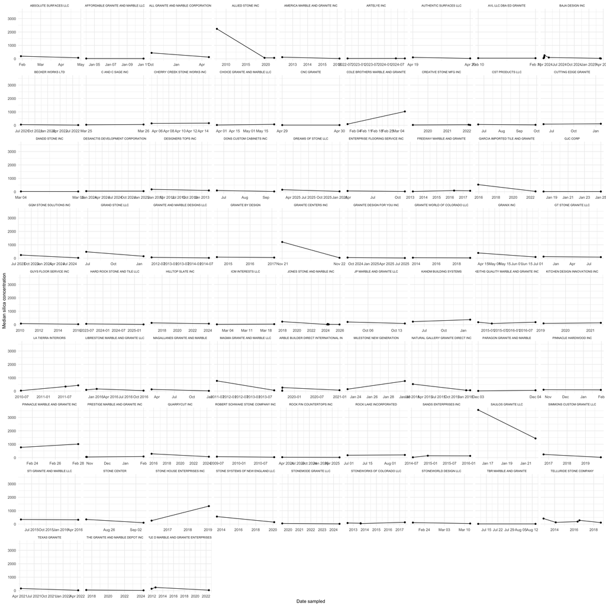

```r
ggplot(est_multi, aes(x = date_sampled, y = median_conc)) +
  geom_line() +
  geom_point() +
  facet_wrap(~ establishment, scales = "free_x") +
  labs(x = "Date sampled", y = "Median silica concentration") +
  theme_minimal() +
  theme(strip.text = element_text(size = 7))
```